# Metaanalysis of ACTH versus oral steroids for infantile spasms

#### Note: To see the code for each analysis, click on the “Code” button.

## Install needed packages

```r
# install.packages("meta")
library (meta)
```

```
## Loading 'meta' package (version 4.9-7).
## Type 'help(meta)' for a brief overview.
```

```r
# install.packages("tidyr")
library (tidyr)
```

```r
# install.packages("ggplot2")
library (ggplot2)
```

## ACTH

#### ACTH data

Data from the studies on the effectiveness of ACTH (probability of resolving infantile spasms 2 weeks after treatment initiation).

```r
# ACTH data
ACTH <- metaprop(
  event = c( 7, 12, 13, 14, 11, 19, 46, 17, 11, 18, 66, 40,  52,  9, 11),
  n = c(    12, 15, 15, 19, 13, 25, 53, 20, 14, 49, 97, 57, 111, 18, 16),
  studlab = c(
              "Hrachovy et al, 1983",
              "Snead et al, 1989",
              "Baram et al, 1996",
              "Vigevano & Cilio, 1997",
              "Yanagaki et al, 1999",
              "Lux et al, 2004",
              "Lin et al, 2006",
              "Kossoff et al, 2008",
              "Cohen-Sadan et al, 2009",
              "Wanigasinghe et al, 2015",
              "Knupp et al, 2016",
              "Hodgeman et al, 2016",
              "Yin et al, 2017",
              "Gowda et al, 2019",
              "Dressler et al, 2019"
  ),
  method="Inverse"
               )
```

#### ACTH forest plot

Forest plot summarizing the data on effectiveness for ACTH for infantile spasms (probability of resolving infantile spasms 2 weeks after treatment initiation).

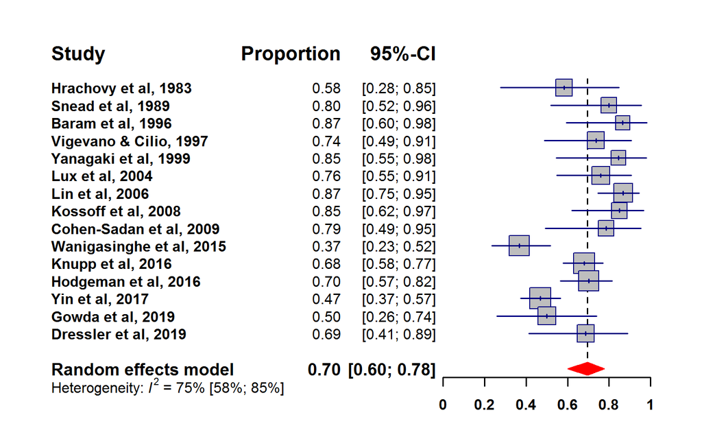

```r
# Forest plot
forest(ACTH, comb.random = TRUE, comb.fixed = FALSE, lty.random=2, lty.fixed = 0, weight.study = "random",
       xlim = c(0, 1), lwd = 1.75, col.study = "navy", col.square = "gray", col.square.lines = "navy",
       col.diamond.random = "red", col.diamond.lines.random = "red",
       print.I2 = TRUE, print.I2.ci = TRUE, print.tau2 = FALSE, print.pval.Q = FALSE,
       fontsize = 12, fs.heading = 16, fs.hetstat = 12, fs.axis = 12, fs.test.overall = 12,
       fs.random = 14, fs.smlab = 14, ff.study.labels =  "bold",
       ff.axis = "bold", squaresize = 1.2,
       backtransf = TRUE, test.overall.random = TRUE,
       leftcols = c("studlab", "effect", "ci"), rightcols = FALSE,
       just = "right", digits = 2)
```

The forest plot for this random-effects meta-analysis shows that the pooled estimated effectiveness (probability of resolving infantile spasms 2 weeks after treatment initiation) of ACTH is 70%, with a 95% confidence interval between 60% and 78%.

It also shows that there is a high between-study heterogeneity with an $I^2$ of 75% (95% confidence interval: 58% to 85%).

#### Cumulative meta-analysis

To evaluate how the global estimate of effectiveness has changed over time, a cumulative meta-analysis calculates how the global estimate evolved as new studies became available over the years.

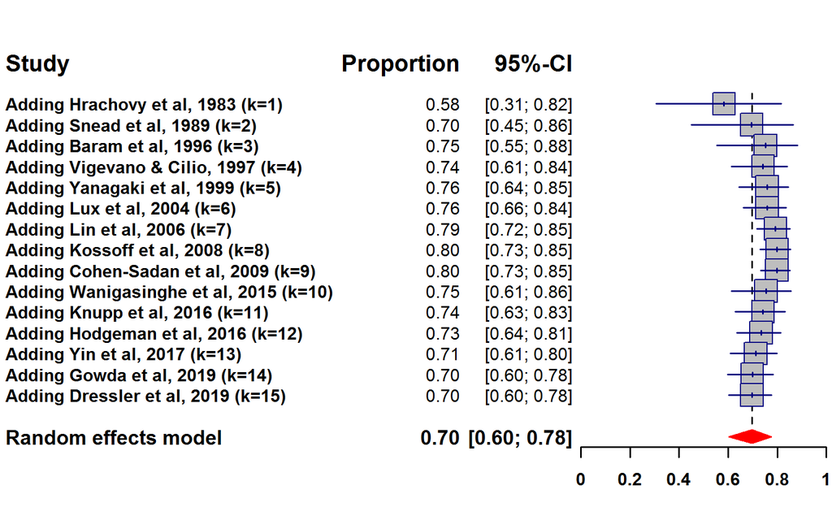

```r
# Cumulative meta-analysis
ACTH_cumulative <- metacum(x=ACTH, pooled="random")

# Cumulative meta-analysis plot
forest(ACTH_cumulative, comb.random = TRUE, comb.fixed = FALSE, lty.random=2, lty.fixed = 0, weight.study = "random",
       xlim = c(0, 1), lwd = 1.75, col.study = "navy", col.square = "gray", col.square.lines = "navy",
       col.diamond.random = "red", col.diamond.lines.random = "red",
       print.I2 = TRUE, print.I2.ci = TRUE, print.tau2 = FALSE, print.pval.Q = FALSE,
       fontsize = 12, fs.heading = 16, fs.hetstat = 12, fs.axis = 12, fs.test.overall = 12,
       fs.random = 14, fs.smlab = 14, ff.study.labels =  "bold",
       ff.axis = "bold", squaresize = 1.2,
       backtransf = TRUE, test.overall.random = TRUE,
       leftcols = c("studlab", "effect", "ci"), rightcols = FALSE,
       just = "right", digits = 2)
```

In the late 2000s, studies with an estimated high effectiveness of ACTH (Lin et al, 2006, Kossoff et al, 2008, and Cohen-Sadan et al, 2009) increased the pooled estimated effectiveness of ACTH to approximately 80%.

In the 2010s, studies with lower estimated effectiveness of ACTH (Yin et al, 2017 and Gowda et al, 2019) brought back the pooled estimated effectiveness of ACTH to approximately 70%.

#### Influence analysis (or leave-one-out analyisis)

To evaluate whether some studies have a specially strong influence in the final pooled estimate, a leave-one-out meta-analysis calculates pooled estimates omitting one study at a time.

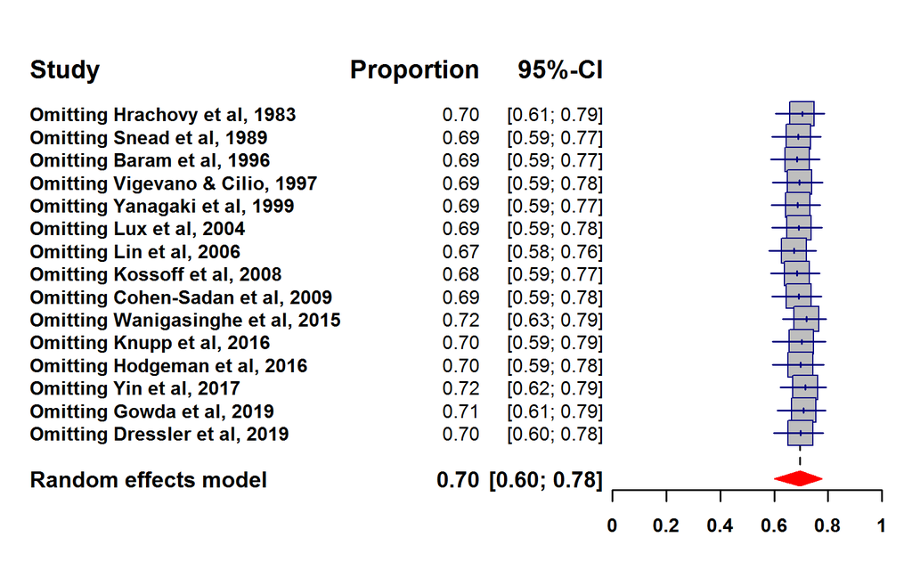

```r
# Leave-one-out meta-analysis
ACTH_leaveoneout <- metainf(x=ACTH, pooled="random")

# Influence analysis plot
forest(ACTH_leaveoneout, comb.random = TRUE, comb.fixed = FALSE, lty.random=2, lty.fixed = 0, weight.study = "random",
       xlim = c(0, 1), lwd = 1.75, col.study = "navy", col.square = "gray", col.square.lines = "navy",
       col.diamond.random = "red", col.diamond.lines.random = "red",
       print.I2 = TRUE, print.I2.ci = TRUE, print.tau2 = FALSE, print.pval.Q = FALSE,
       fontsize = 12, fs.heading = 16, fs.hetstat = 12, fs.axis = 12, fs.test.overall = 12,
       fs.random = 14, fs.smlab = 14, ff.study.labels =  "bold",
       ff.axis = "bold", squaresize = 1.2,
       backtransf = TRUE, test.overall.random = TRUE,
       leftcols = c("studlab", "effect", "ci"), rightcols = FALSE,
       just = "right", digits = 2)
```

This influence analysis plot shows that no individual study markedly influenced the final pooled estimate: leaving out each of the studies at a time does not markedly change the global estimate.

#### Evaluation of publication bias

Small studies tend to have more extreme results (either more positive or more negative results) just because a smaller sample size leads to more variability in the estimate than a larger sample size.

However, positive results tend to be published more often than negative results, leading to publication bias.

We evaluate publication bias visually through a funnel plot.

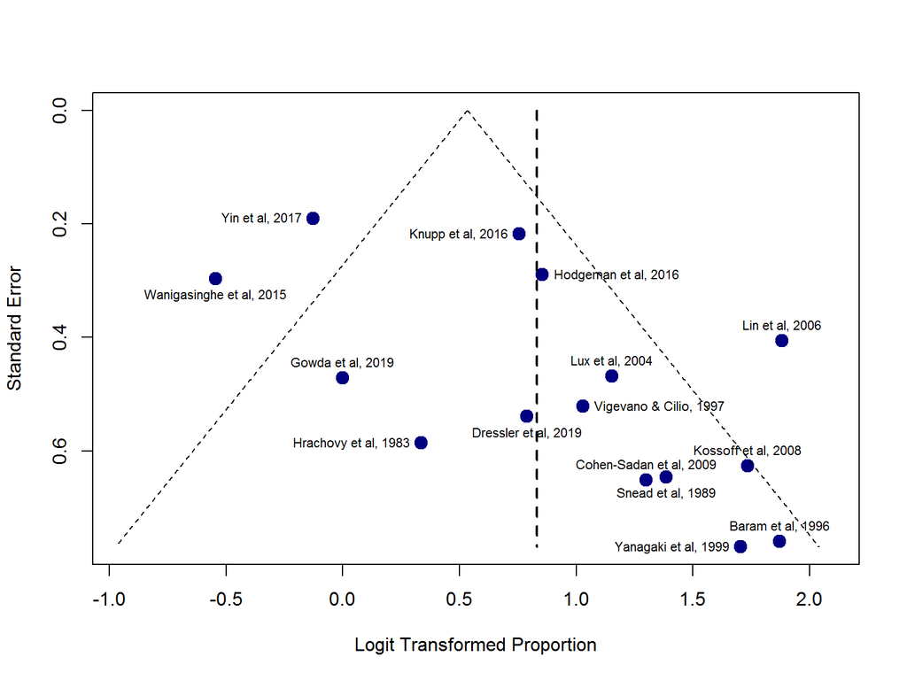

```r
# Funnel plot names
funnel(ACTH, comb.fixed = FALSE, comb.random = TRUE, pch = 21, cex = 1.5,
       lty.random = 2, lwd.random = 2, bg = "navy", col = "navy",
       studlab = TRUE, cex.studlab = 0.7, pos.studlab = c(2, 1, 3, 4, 2, 3, 3, 3, 3, 1, 2, 4, 2, 3, 1))
```

This funnel plot shows that small studies (low on the y-axis) tend to have estimates of the effectiveness of ACTH higher (right on the x-axis) than larger studies suggesting some degree of publication bias leading to some degree of overestimation of the effectiveness of ACTH.

#### Estimation of the effect of ACTH adjusting for the potential publication bias with the trim-and-fill method.

The trim and fill method artificially compensates for the studies that are probably causing publication bias (small studies that are distributed asymmetrically) artificially creating small studies simetrically distributed from the existing small studies (studies which probably existed but probably were not published).

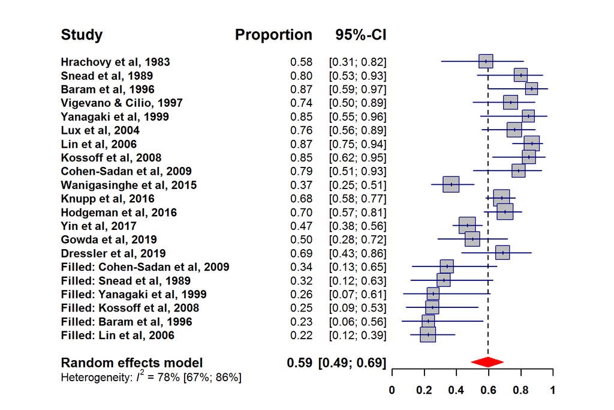

```r
# ACTH data trimandfill
ACTH_trimandfill <- trimfill(ACTH, ma.fixed = TRUE, comb.random = TRUE)

# Forest plot
forest(ACTH_trimandfill, comb.fixed = FALSE, lty.random=2, lty.fixed = 0,
       xlim=c(0, 1), lwd = 1.75, col.study = "navy", col.square = "gray", col.square.lines = "navy",
       col.diamond.random = "red", col.diamond.lines.random = "red",
       print.I2 = TRUE, print.I2.ci = TRUE, print.tau2 = FALSE, print.pval.Q = FALSE,
       fontsize = 12, fs.heading = 16, fs.hetstat = 12, fs.axis = 12, fs.test.overall = 12,
       fs.random = 14, fs.smlab = 14, ff.study.labels =  "bold",
       ff.axis = "bold", squaresize = 1.2,
       backtransf = TRUE, test.overall.random = FALSE,
       leftcols = c("studlab", "effect", "ci"), rightcols = FALSE,
       just = "right", digits = 2, print.zval = FALSE, label.test.overall.random = FALSE)
```

The forest plot imputing studies that “adjust” for potential publication bias show that, potentially, without publication bias, the pooled estimate of effectiveness of ACTH would be approximately 59% with a 95% confidence interval from 49% to 69%.

That is markedly lower than the unadjusted estimate of 70%, with a 95% confidence interval from 60% to 78%. This suggests that the effectiveness of ACTH around 70% is probably inflated through publication bias.

#### Evaluation of publication bias in the trimmed and filled data

We evaluate publication bias visually through a funnel plot.

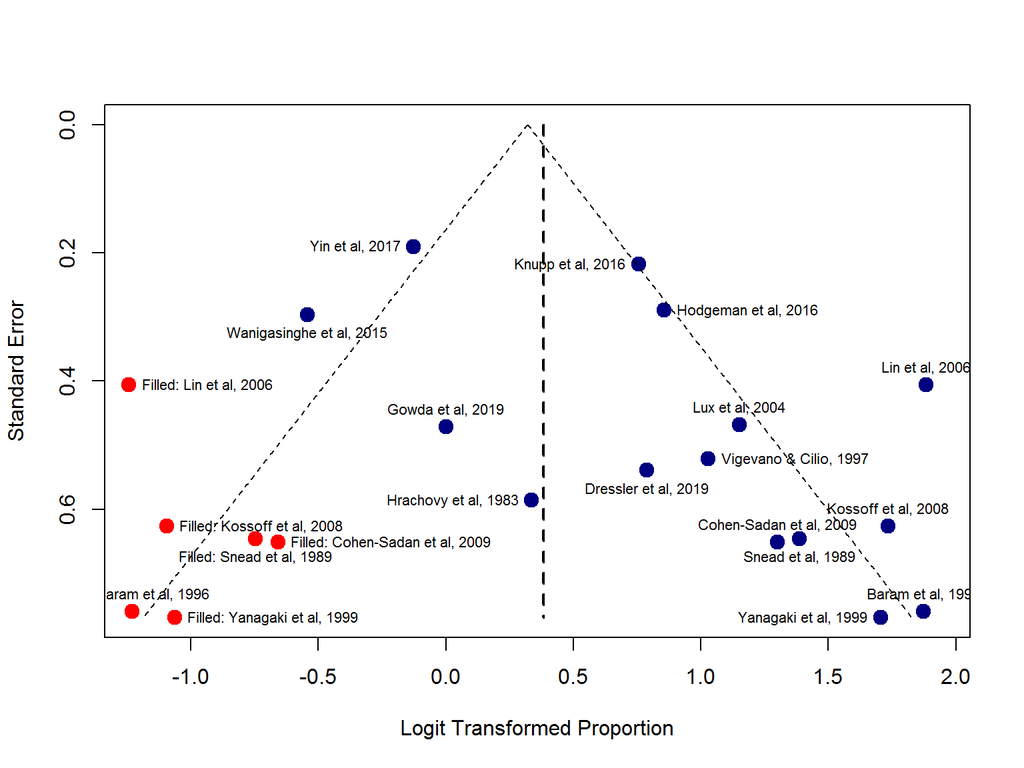

```r
# Funnel plot
funnel(ACTH_trimandfill, comb.fixed = FALSE, comb.random = TRUE, pch = 21, cex = 1.5,
       lty.random = 2, lwd.random = 2,
       bg = c("navy", "navy", "navy", "navy", "navy", "navy", "navy", "navy", "navy", "navy", "navy", "navy", "navy", "navy", "navy", "red", "red", "red", "red", "red", "red"),
       col = c("navy", "navy", "navy", "navy", "navy", "navy", "navy", "navy", "navy", "navy", "navy", "navy", "navy", "navy", "navy", "red", "red", "red", "red", "red", "red"),
       studlab = TRUE, cex.studlab = 0.7, pos.studlab = c(2, 1, 3, 4, 2, 3, 3, 3, 3, 1, 2, 4, 2, 3, 1, 4, 1, 4, 4, 3, 4))
```

Obviously, “adjusting” for potential publication bias shows a more balanced plot. In red, the inputted studies to compensate for potential publication bias.

## Prednisolone

#### Prednisolone data

Data from the studies on the effectiveness of prednisolone (probability of resolving infantile spasms 2 weeks after treatment initiation).

```r
# Prednisolone data
PRD <- metaprop(
  event = c( 21, 13, 7, 16, 28, 16, 30, 56, 60,  28,  5),
  n = c(     30, 17, 7, 31, 48, 20, 54, 87, 102, 39, 15),
  studlab = c(
              "Lux et al, 2004",
              "Ware et al, 2012",
              "Adhami & Harini, 2013",
              "Chellamuthu et al, 2014",
              "Wanigasinghe et al, 2015",
              "Yi et al, 2015",
              "Knupp et al, 2016",
              "Gonzalez-Giraldo et al, 2018",
              "Eliyan et al, 2019",
              "Yi et al, 2019",
              "Gowda et al, 2019"
  ),
  method="Inverse"
               )
```

##### Prednisolone forest plot

Forest plot summarizing the data on effectiveness for prednisolone for infantile spasms (probability of resolving infantile spasms 2 weeks after treatment initiation).

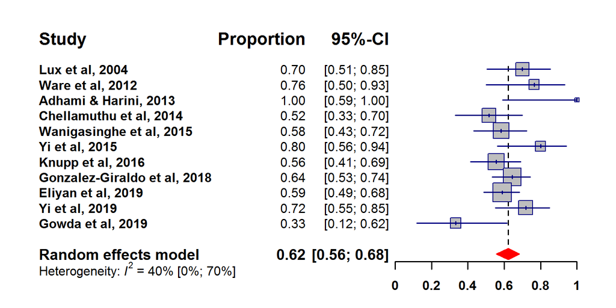

```r
# Forest plot
forest(PRD, comb.fixed = FALSE, lty.random=2, lty.fixed = 0,
       xlim = c(0, 1), lwd = 1.75, col.study = "navy", col.square = "gray", col.square.lines = "navy",
       col.diamond.random = "red", col.diamond.lines.random = "red",
       print.I2 = TRUE, print.I2.ci = TRUE, print.tau2 = FALSE, print.pval.Q = FALSE,
       fontsize = 12, fs.heading = 16, fs.hetstat = 12, fs.axis = 12, fs.test.overall = 12,
       fs.random = 14, fs.smlab = 14, ff.study.labels =  "bold",
       ff.axis = "bold", squaresize = 1.2,
       backtransf = TRUE, test.overall.random = TRUE,
       leftcols = c("studlab", "effect", "ci"), rightcols = FALSE,
       just = "right", digits = 2)
```

The forest plot for this random-effects meta-analysis shows that the estimated effectiveness (probability of resolving infantile spasms 2 weeks after treatment initiation) of prednisolone is 62%, with a 95% confidence interval between 56% and 68%.

#### Cumulative meta-analysis

To evaluate how the global estimate of effectiveness has changed over time, a cumulative meta-analysis calculates how the global estimate evolved as new studies became available over the years.

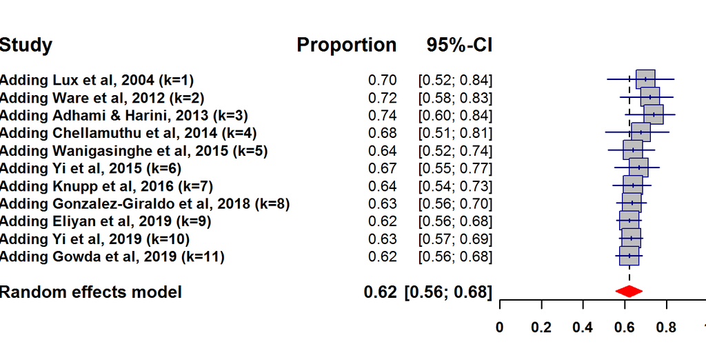

```r
# Cumulative meta-analysis
PRD_cumulative <- metacum(x=PRD, pooled="random")

# Cumulative meta-analysis plot
forest(PRD_cumulative, comb.random = TRUE, comb.fixed = FALSE, lty.random=2, lty.fixed = 0, weight.study = "random",
       xlim = c(0, 1), lwd = 1.75, col.study = "navy", col.square = "gray", col.square.lines = "navy",
       col.diamond.random = "red", col.diamond.lines.random = "red",
       print.I2 = TRUE, print.I2.ci = TRUE, print.tau2 = FALSE, print.pval.Q = FALSE,
       fontsize = 12, fs.heading = 16, fs.hetstat = 12, fs.axis = 12, fs.test.overall = 12,
       fs.random = 14, fs.smlab = 14, ff.study.labels =  "bold",
       ff.axis = "bold", squaresize = 1.2,
       backtransf = TRUE, test.overall.random = TRUE,
       leftcols = c("studlab", "effect", "ci"), rightcols = FALSE,
       just = "right", digits = 2)
```

This cumulative meta-analysis plot shows that the pooled estimate of effectiveness of prednisolone started around 70% in the 2000s and early 2010s, but based on a limited number of studies.

From 2014 to 2019 there have been many more studies on the effectiveness of prednisolone for infantile spasms, which stabilized its estimated pooled effectiveness at approximately 62%.

#### Influence analysis (or leave-one-out analyisis)

To evaluate whether some studies have a specially strong influence in the final pooled estimate, a leave-one-out meta-analysis calculates pooled estimates omitting one study at a time.

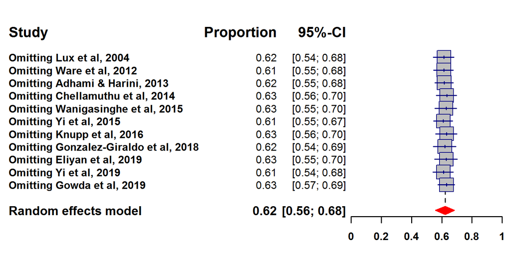

```r
# Leave-one-out meta-analysis
PRD_leaveoneout <- metainf(x=PRD, pooled="random")

# Influence analysis plot
forest(PRD_leaveoneout, comb.random = TRUE, comb.fixed = FALSE, lty.random=2, lty.fixed = 0, weight.study = "random",
       xlim = c(0, 1), lwd = 1.75, col.study = "navy", col.square = "gray", col.square.lines = "navy",
       col.diamond.random = "red", col.diamond.lines.random = "red",
       print.I2 = TRUE, print.I2.ci = TRUE, print.tau2 = FALSE, print.pval.Q = FALSE,
       fontsize = 12, fs.heading = 16, fs.hetstat = 12, fs.axis = 12, fs.test.overall = 12,
       fs.random = 14, fs.smlab = 14, ff.study.labels =  "bold",
       ff.axis = "bold", squaresize = 1.2,
       backtransf = TRUE, test.overall.random = TRUE,
       leftcols = c("studlab", "effect", "ci"), rightcols = FALSE,
       just = "right", digits = 2)
```

This influence analysis plot shows that no individual study markedly influenced the final pooled estimate: leaving out each of the studies at a time does not markedly change the global estimate.

#### Evaluation of publication bias

Small studies tend to have more extreme results (either more positive or more negative results) just because a smaller sample size leads to more variability in the estimate than a larger sample size.

However, positive results tend to be published more often than negative results, leading to publication bias.

We evaluate publication bias visually through a funnel plot.

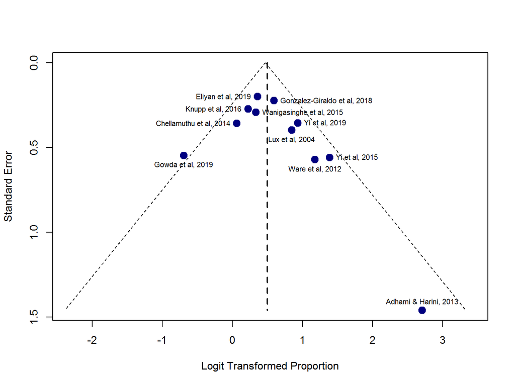

```r
# Funnel plot names
funnel(PRD, comb.fixed = FALSE, comb.random = TRUE, pch = 21, cex = 1.5,
       lty.random = 2, lwd.random = 2, bg = "navy", col = "navy",
       studlab = TRUE, cex.studlab = 0.7, pos.studlab = c(1, 1, 3, 2, 4, 4, 2, 4, 2, 4, 1))
```

This funnel plot shows that small studies (low on the y-axis) tend to have estimates of the effectiveness of prednisolone higher (right on the x-axis) than larger studies suggesting some degree of publication bias leading to some degree of overestimation of the effectiveness of prednisolone.

#### Estimation of the effect of prednisolone adjusting for the potential publication bias with the trim-and-fill method.

The trim and fill method artificially compensates for the studies that are probably causing publication bias (small studies that are distributed asymmetrically) artificially creating small studies simetrically distributed from the existing small studies (studies which probably existed but probably were not published).

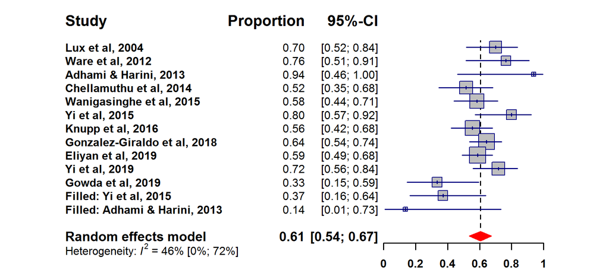

```r
# Prednisolone data trimandfill
PRD_trimandfill <- trimfill(PRD, ma.fixed = TRUE, comb.random = TRUE)

# Forest plot
forest(PRD_trimandfill, comb.fixed = FALSE, lty.random=2, lty.fixed = 0,
       xlim=c(0, 1), lwd = 1.75, col.study = "navy", col.square = "gray", col.square.lines = "navy",
       col.diamond.random = "red", col.diamond.lines.random = "red",
       print.I2 = TRUE, print.I2.ci = TRUE, print.tau2 = FALSE, print.pval.Q = FALSE,
       fontsize = 12, fs.heading = 16, fs.hetstat = 12, fs.axis = 12, fs.test.overall = 12,
       fs.random = 14, fs.smlab = 14, ff.study.labels =  "bold",
       ff.axis = "bold", squaresize = 1.2,
       backtransf = TRUE, test.overall.random = FALSE,
       leftcols = c("studlab", "effect", "ci"), rightcols = FALSE,
       just = "right", digits = 2, print.zval = FALSE, label.test.overall.random = FALSE)
```

The forest plot imputing studies that “adjust” for potential publication bias show that, potentially, without publication bias, the pooled estimate of effectiveness of prednisolone would be approximately 61% with a 95% confidence interval from 54% to 67%.

That is very similar to the unadjusted estimate of 62%, with a 95% confidence interval from 56% to 68%. This suggests that the effectiveness of prednisolone around 62% is probably not inflated through publication bias.

#### Evaluation of publication bias in the trimmed and filled data

We evaluate publication bias visually through a funnel plot.

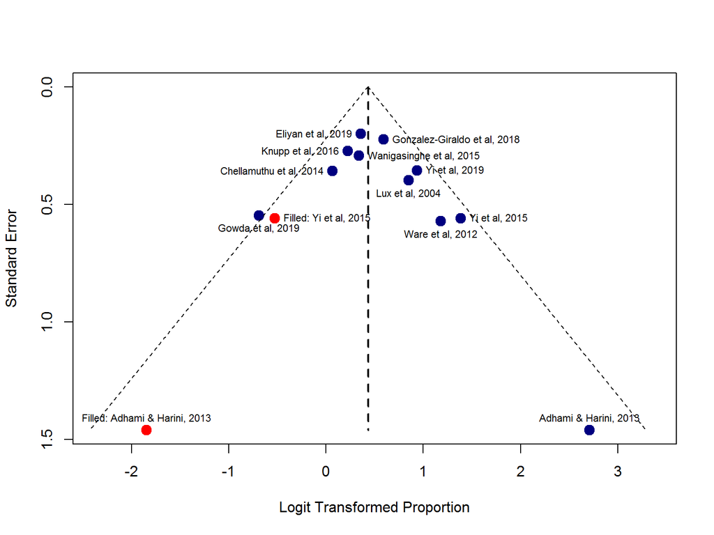

```r
# Funnel plot
funnel(PRD_trimandfill, comb.fixed = FALSE, comb.random = TRUE, pch = 21, cex = 1.5,
       lty.random = 2, lwd.random = 2,
       bg = c("navy", "navy", "navy", "navy", "navy", "navy", "navy", "navy", "navy", "navy", "navy", "red", "red"),
       col = c("navy", "navy", "navy", "navy", "navy", "navy", "navy", "navy", "navy", "navy", "navy", "red", "red"),
       studlab = TRUE, cex.studlab = 0.7, pos.studlab = c(1, 1, 3, 2, 4, 4, 2, 4, 2, 4, 1, 4, 3))
```

Obviously, “adjusting” for potential publication bias shows a more balanced plot. In red, the inputted studies to compensate for potential publication bias.

## Comparison ACTH versus prednisolone

#### Data on the comparison between ACTH and prednisolone

Data from the studies on the effectiveness of ACTH and prednisolone for infantile spasms.

```r
# Meta-analysis considering subgroups by groups: ACTH and prednisolone
COMPARISON_ACTH_PRD <- metaprop(event = c(7, 12, 13, 14, 11, 19, 46, 17, 11, 18, 66, 40,  52,  9, 11, ### ACTH
                                        21, 13, 7, 16, 28, 16, 30, 56, 60,  28,  5),          ### Prednisolone

               n = c(              12, 15, 15, 19, 13, 25, 53, 20, 14, 49, 97, 57, 111, 18, 16,       ### ACTH
                                   30, 17, 7, 31, 48, 20, 54, 87, 102, 39, 15),               ### Prednisolone

               c("Hrachovy et al, 1983",
              "Snead et al, 1989",
              "Baram et al, 1996",
              "Vigevano & Cilio, 1997",
              "Yanagaki et al, 1999",
              "Lux et al, 2004",
              "Lin et al, 2006",
              "Kossoff et al, 2008",
              "Cohen-Sadan et al, 2009",
              "Wanigasinghe et al, 2015",
              "Knupp et al, 2016",
              "Hodgeman et al, 2016",
              "Yin et al, 2017",
              "Gowda et al, 2019",
              "Dressler et al, 2019",                                                                ### ACTH

              "Lux et al, 2004",
              "Ware et al, 2012",
              "Adhami & Harini, 2013",
              "Chellamuthu et al, 2014",
              "Wanigasinghe et al, 2015",
              "Yi et al, 2015",
              "Knupp et al, 2016",
              "Gonzalez-Giraldo et al, 2018",
              "Eliyan et al, 2019",
              "Yi et al, 2019",
              "Gowda et al, 2019"),                                                          ### Prednisolone


               byvar = c("ACTH", "ACTH", "ACTH", "ACTH", "ACTH", "ACTH",
                         "ACTH", "ACTH", "ACTH", "ACTH", "ACTH", "ACTH",
                         "ACTH", "ACTH", "ACTH",                                                     ### ACTH

                         "Prednisolone", "Prednisolone", "Prednisolone", "Prednisolone",
                         "Prednisolone", "Prednisolone", "Prednisolone", "Prednisolone",
                         "Prednisolone", "Prednisolone", "Prednisolone"),                     ### Prednisolone
  method="Inverse"
               )
```

#### Forest plot for the comparison of effectiveness between ACTH and prednisolone

Forest plot summarizing the data on effectiveness (probability of resolving infantile spasms 2 weeks after treatment initiation) for ACTH and for prednisolone.

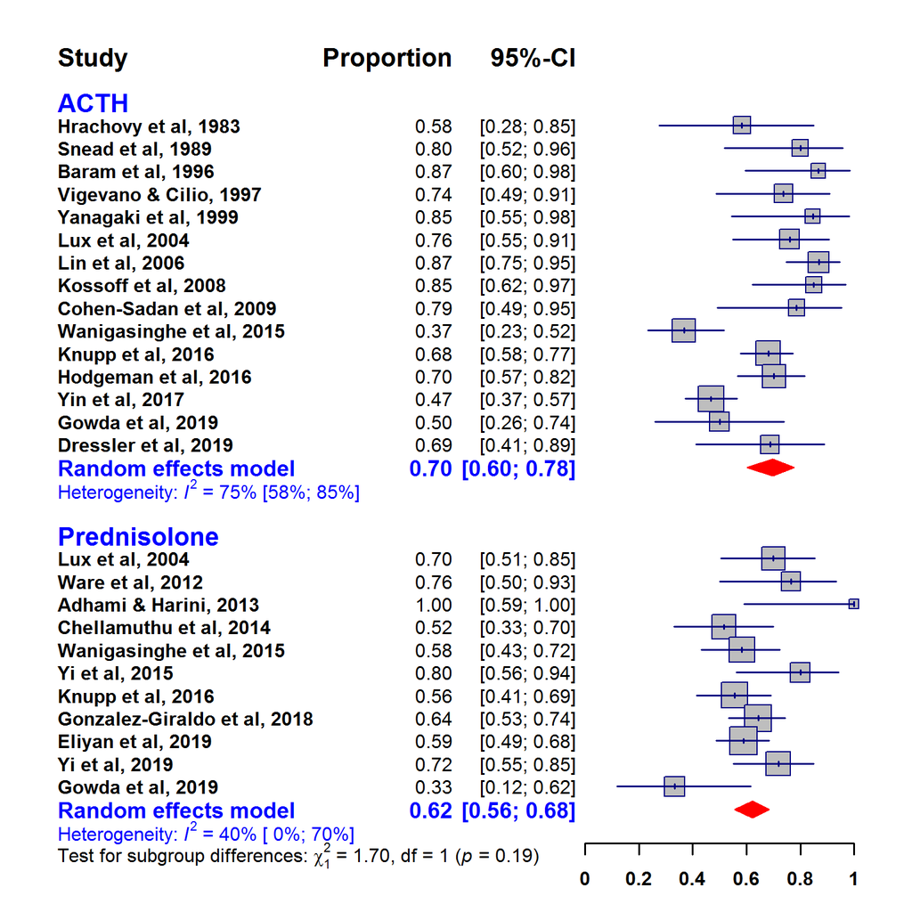

```r
forest(COMPARISON_ACTH_PRD, comb.fixed = FALSE, lty.random=2, lty.fixed = 0,
       xlim = c(0, 1), lwd = 1.75, col.study = "navy", col.square = "gray", col.square.lines = "navy",
       col.diamond.random = "red", col.diamond.lines.random = "red",
       print.I2 = TRUE, print.I2.ci = TRUE, print.tau2 = FALSE, print.pval.Q = FALSE,
       fontsize = 12, fs.heading = 16, fs.hetstat = 12, fs.axis = 12, fs.test.overall = 12,
       fs.random = 14, fs.smlab = 14, ff.study.labels =  "bold",
       ff.axis = "bold", squaresize = 1.2,
       backtransf = TRUE, test.overall.random = TRUE,
       leftcols = c("studlab", "effect", "ci"), rightcols = FALSE,
       just = "right", digits = 2, bylab = "MEDICATION",
       print.byvar = FALSE, col.by = "blue", overall = FALSE, overall.hetstat = FALSE,
       test.subgroup.random = TRUE, fs.test.subgroup.random = 15)
```

This forest plot shows that the pooled estimation of effectiveness for ACTH: 70% (95% confidence interval: 60% to 78%) is not statistically significantly different than the pooled estimated of effectiveness for prednisolone: 62% (95% confidence interval: 56% to 68%) with a p-value of 0.19.

#### Data on the comparison between ACTH and prednisolone adjusting for potential publication bias

Data from the studies on the effectiveness of ACTH and prednisolone for infantile spasms.

```r
# Meta-analysis considering ACTH and prednisolone with data adjusted for potential publication bias
COMPARISON_ACTH_PRD_trimandfill <- metagen(TE = c(ACTH_trimandfill$TE,         ### ACTH
                                                  PRD_trimandfill$TE),         ### Prednisolone

               seTE = c(              ACTH_trimandfill$seTE,                   ### ACTH
                                      PRD_trimandfill$seTE),                   ### Prednisolone

               studlab = c(ACTH_trimandfill$studlab,                           ### ACTH
                           PRD_trimandfill$studlab),                           ### Prednisolone


               byvar = c(
                         rep("ACTH", length(ACTH_trimandfill$studlab)),         ### ACTH
                         rep("Prednisolone", length(PRD_trimandfill$studlab))   ### Prednisolone
),
  sm = "PLOGIT"
               )
```

#### Forest plot for the comparison of effectiveness between ACTH and prednisolone adjusting for potential publication bias

Forest plot summarizing the data on effectiveness (probability of resolving infantile spasms 2 weeks after treatment initiation) for ACTH and for prednisolone adjusting for potential publication bias.

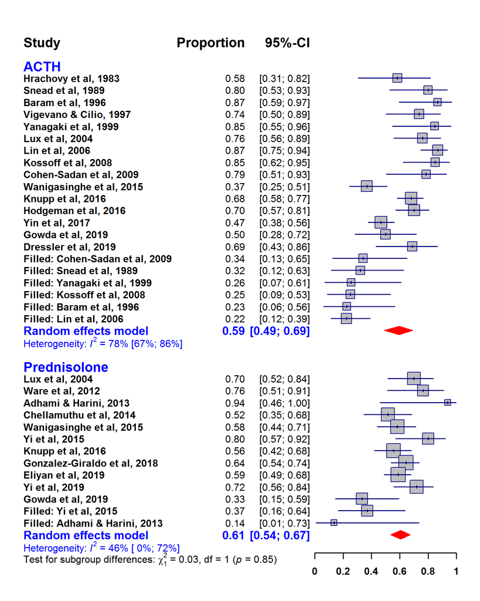

```r
forest(COMPARISON_ACTH_PRD_trimandfill, comb.fixed = FALSE, lty.random=2, lty.fixed = 0,
       xlim = c(0, 1), lwd = 1.75, col.study = "navy", col.square = "gray", col.square.lines = "navy",
       col.diamond.random = "red", col.diamond.lines.random = "red",
       print.I2 = TRUE, print.I2.ci = TRUE, print.tau2 = FALSE, print.pval.Q = FALSE,
       fontsize = 12, fs.heading = 16, fs.hetstat = 12, fs.axis = 12, fs.test.overall = 12,
       fs.random = 14, fs.smlab = 14, ff.study.labels =  "bold",
       ff.axis = "bold", squaresize = 1.2,
       backtransf = TRUE, test.overall.random = TRUE,
       leftcols = c("studlab", "effect", "ci"), rightcols = FALSE,
       just = "right", digits = 2, bylab = "MEDICATION",
       print.byvar = FALSE, col.by = "blue", overall = FALSE, overall.hetstat = FALSE,
       test.subgroup.random = TRUE, fs.test.subgroup.random = 15)
```

This forest plot shows that the pooled estimation of effectiveness (adjusting for potential publication bias) for ACTH: 59% (95% confidence interval: 49% to 69%) is not statistically significantly different than the pooled estimated of effectiveness for prednisolone: 61% (95% confidence interval: 54% to 67%) with a p-value of 0.85.

## Comparison using only randomized clinical trials with direct comparisons

Comparing the effectiveness of two treatments using estimates from different studies in different populations is subject to bias because the underlying populations may have a different underlying severity. For example, if a study estimates the effectiveness of ACTH at 80% and a different study estimates the effectiveness of prednisolone at 55%, this difference can reflect that ACTH is more effective, but it can also reflect that the population in the study on prednisolone had more severe infantile spasms and was, at baseline, more resistant to treatment.

Although this effect becomes less important when the number of compared studies is large (because the underlying severity of the populations in the different studies tend to even out with large numbers), we performed a meta-analysis using only direct comparisons of randomized clinical trials.

#### Data on the comparison using only randomized clinical trials with direct comparisons

Data from the studies on the efficacy of ACTH and prednisolone for infantile spasms. The estimates of the comparisons are the odds ratios and their standard errors in a logarithmic scale, extracted from the 2x2 tables from the original data in the articles.

```r
## Odds ratios
Lux2004_2x2table <- matrix(c(19, 21, 6, 9), nrow=2, ncol=2, dimnames = list(c("ACTH", "Prednisolone"), c("Spasms resolution", "No spasms resolution")))
a <- Lux2004_2x2table[1]
b <- Lux2004_2x2table[3]
c <- Lux2004_2x2table[2]
d <- Lux2004_2x2table[4]
Lux2004__OR <- (a/c) / (b/d)
Lux2004__logseOR <- sqrt((1/a + 1/b + 1/c + 1/d))

Wanigasinghe2015_2x2table <- matrix(c(18, 28, 31, 20), nrow=2, ncol=2, dimnames = list(c("ACTH", "Prednisolone"), c("Spasms resolution", "No spasms resolution")))
a <- Wanigasinghe2015_2x2table[1]
b <- Wanigasinghe2015_2x2table[3]
c <- Wanigasinghe2015_2x2table[2]
d <- Wanigasinghe2015_2x2table[4]
Wanigasinghe2015__OR <- (a/c) / (b/d)
Wanigasinghe2015__logseOR <- sqrt((1/a + 1/b + 1/c + 1/d))

Gowda2019_2x2table <- matrix(c(9, 5, 9, 10), nrow=2, ncol=2, dimnames = list(c("ACTH", "Prednisolone"), c("Spasms resolution", "No spasms resolution")))
a <- Gowda2019_2x2table[1]
b <- Gowda2019_2x2table[3]
c <- Gowda2019_2x2table[2]
d <- Gowda2019_2x2table[4]
Gowda2019__OR <- (a/c) / (b/d)
Gowda2019__logseOR <- sqrt((1/a + 1/b + 1/c + 1/d))


# Meta-analysis considering subgroups by groups: ACTH and prednisolone
DIRECT_COMPARISON_ACTH_PRD <- metagen(TE = c(log(Lux2004__OR), log(Wanigasinghe2015__OR), log(Gowda2019__OR)),

                              seTE = c(Lux2004__logseOR, Wanigasinghe2015__logseOR, Gowda2019__logseOR),

              studlab = c("Lux et al, 2004",
              "Wanigasinghe et al, 2015",
              "Gowda et al, 2019"),
              sm = "OR",
              comb.fixed = FALSE,
              comb.random = TRUE,
              prediction = FALSE
               )
```

#### Forest plot for the comparison of efficacy between ACTH and prednisolone

Forest plot summarizing the data on efficacy (probability of resolving infantile spasms 2 weeks after treatment initiation) for ACTH and for prednisolone.

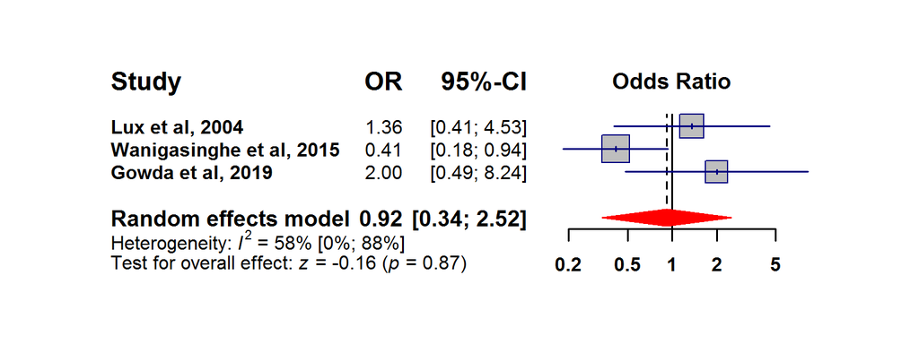

```r
# Forest plot
forest(DIRECT_COMPARISON_ACTH_PRD, comb.random = TRUE, comb.fixed = FALSE, lty.random=2, lty.fixed = 0,
       lwd = 1.75, col.study = "navy", col.square = "gray", col.square.lines = "navy",
       col.diamond.random = "red", col.diamond.lines.random = "red",
       print.I2 = TRUE, print.I2.ci = TRUE, print.tau2 = FALSE, print.pval.Q = FALSE,
       fontsize = 12, fs.heading = 16, fs.hetstat = 12, fs.axis = 12, fs.test.overall = 12,
       fs.random = 14, fs.smlab = 14, ff.study.labels =  "bold",
       ff.axis = "bold", squaresize = 1.2,
       backtransf = TRUE, test.overall.random = TRUE,
       leftcols = c("studlab", "effect", "ci"), rightcols = FALSE,
       just = "right", digits = 2)
```

This forest plot shows that the pooled estimation of the comparison of efficacy for ACTH versus prednisolone has an odds ratio of 0.92 (95% confidence interval: 0.34 to 2.52) and is not statistically significantly different than the null odds ratio value of 1 with a p-value of 0.87.

It also shows that the heterogeneity is moderate with an $I^2$ of 58% (95% confidence interval: 0% to 88%).

#### Cumulative meta-analysis

To evaluate how the global estimate of efficacy has changed over time, a cumulative meta-analysis calculates how the global estimate evolved as new studies became available over the years.

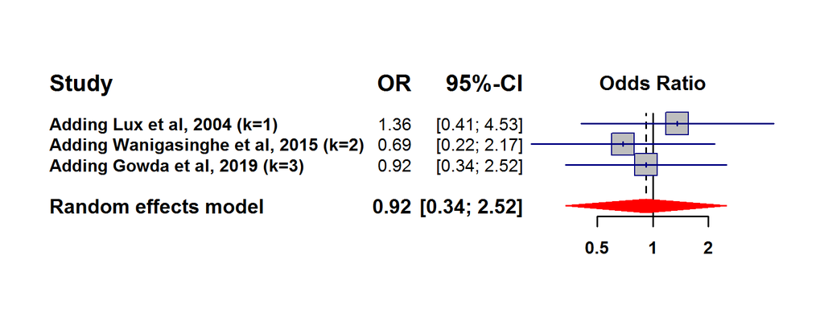

```r
# Cumulative meta-analysis
DIRECT_COMPARISON_ACTH_PRD_cumulative <- metacum(x=DIRECT_COMPARISON_ACTH_PRD, pooled="random")

# Cumulative meta-analysis plot
forest(DIRECT_COMPARISON_ACTH_PRD_cumulative, comb.random = TRUE, comb.fixed = FALSE, lty.random=2, lty.fixed = 0,
       lwd = 1.75, col.study = "navy", col.square = "gray", col.square.lines = "navy",
       col.diamond.random = "red", col.diamond.lines.random = "red",
       print.I2 = TRUE, print.I2.ci = TRUE, print.tau2 = FALSE, print.pval.Q = FALSE,
       fontsize = 12, fs.heading = 16, fs.hetstat = 12, fs.axis = 12, fs.test.overall = 12,
       fs.random = 14, fs.smlab = 14, ff.study.labels =  "bold",
       ff.axis = "bold", squaresize = 1.2,
       backtransf = TRUE, test.overall.random = TRUE,
       leftcols = c("studlab", "effect", "ci"), rightcols = FALSE,
       just = "right", digits = 2)
```

This cumulative meta-analysis plot shows that the pooled estimate of efficacy of ACTH versus prednisolone was initially in favor of ACTH when only Lux et al, 2004 was considered, but then Wanigasinghe et al, 2015 pulled the estimate towards prednisolone being more efficacious. Finally, Gowda et al, 2019 pulled the estimate back towards the null value of odds ratio 1.

At any stage in time, all estimates had confidence intervals that include the null value for odds ratio of 1 (not statistically significant).

#### Influence analysis (or leave-one-out analyisis)

To evaluate whether some studies have a specially strong influence in the final pooled estimate, a leave-one-out meta-analysis calculates pooled estimates omitting one study at a time.

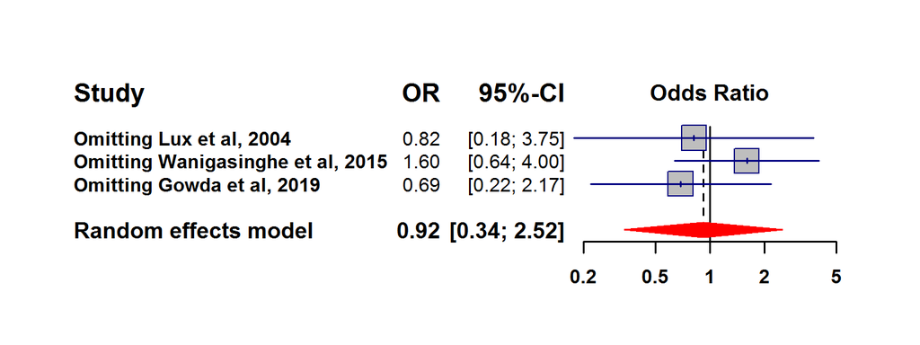

```r
# Leave-one-out meta-analysis
DIRECT_COMPARISON_ACTH_PRD_leaveoneout <- metainf(x=DIRECT_COMPARISON_ACTH_PRD, pooled="random")

# Influence analysis plot
forest(DIRECT_COMPARISON_ACTH_PRD_leaveoneout, comb.random = TRUE, comb.fixed = FALSE, lty.random=2, lty.fixed = 0,
       lwd = 1.75, col.study = "navy", col.square = "gray", col.square.lines = "navy",
       col.diamond.random = "red", col.diamond.lines.random = "red",
       print.I2 = TRUE, print.I2.ci = TRUE, print.tau2 = FALSE, print.pval.Q = FALSE,
       fontsize = 12, fs.heading = 16, fs.hetstat = 12, fs.axis = 12, fs.test.overall = 12,
       fs.random = 14, fs.smlab = 14, ff.study.labels =  "bold",
       ff.axis = "bold", squaresize = 1.2,
       backtransf = TRUE, test.overall.random = TRUE,
       leftcols = c("studlab", "effect", "ci"), rightcols = FALSE,
       just = "right", digits = 2)
```

This influence analysis plot shows that Wanigasinghe et al, 2015 markedly influenced the final pooled estimate: leaving that study out (using only the other two studies) yields an odds ratio of the estimate of the efficacy of ACTH versus prednisolone of 1.60 (95% confidence interval: 0.64 to 4), still far from statistically significant but suggesting that ACTH might be somewhat more efficacious if the population of Wanigasinghe et al, 2015 is not generalizable to other settings.

#### Evaluation of publication bias

With only three studies, it is difficult to evaluate publication bias. However, we evaluated publication bias visually through a funnel plot.

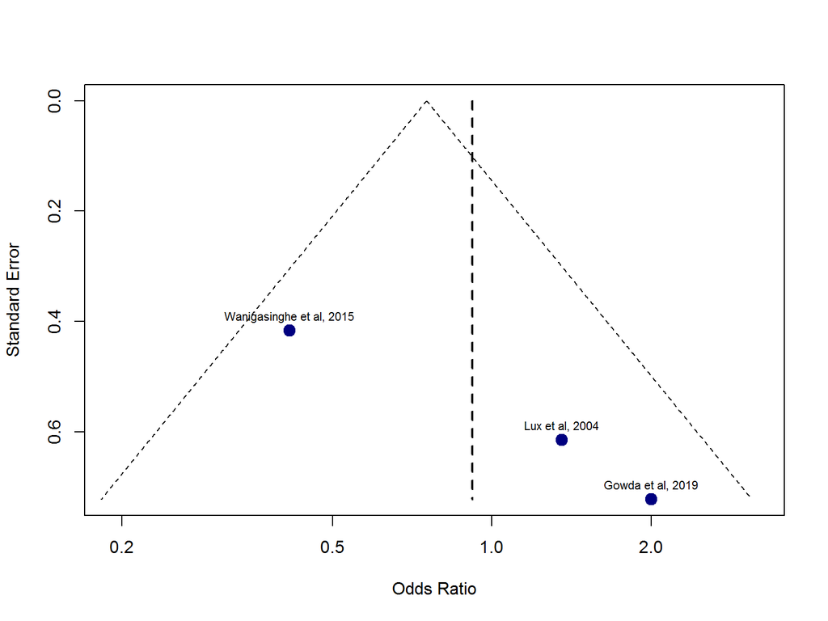

```r
# Funnel plot names
funnel(DIRECT_COMPARISON_ACTH_PRD, comb.fixed = FALSE, comb.random = TRUE, pch = 21, cex = 1.5,
       lty.random = 2, lwd.random = 2, bg = "navy", col = "navy",
       studlab = TRUE, cex.studlab = 0.7, pos.studlab = c(3, 3, 3))
```

#### Estimation of the effect of ACTH versus prednisolone adjusting for the potential publication bias with the trim-and-fill method.

The trim and fill method artificially compensates for the studies that are probably causing publication bias (small studies that are distributed asymmetrically) artificially creating small studies simetrically distributed from the existing small studies (studies which probably existed but probably were not published).

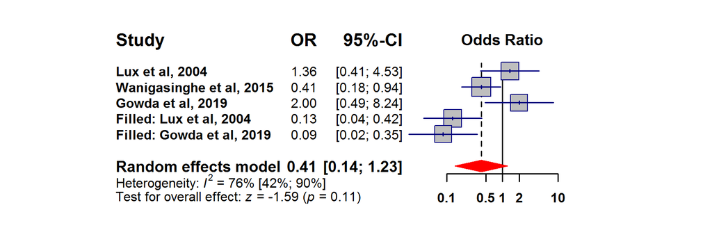

```r
# ACTH versus prednisolone data trimandfill
DIRECT_COMPARISON_ACTH_PRD_trimandfill <- trimfill(DIRECT_COMPARISON_ACTH_PRD, ma.fixed = TRUE, comb.random = TRUE)

# Forest plot
forest(DIRECT_COMPARISON_ACTH_PRD_trimandfill, comb.random = TRUE, comb.fixed = FALSE, lty.random=2, lty.fixed = 0,
       lwd = 1.75, col.study = "navy", col.square = "gray", col.square.lines = "navy",
       col.diamond.random = "red", col.diamond.lines.random = "red",
       print.I2 = TRUE, print.I2.ci = TRUE, print.tau2 = FALSE, print.pval.Q = FALSE,
       fontsize = 12, fs.heading = 16, fs.hetstat = 12, fs.axis = 12, fs.test.overall = 12,
       fs.random = 14, fs.smlab = 14, ff.study.labels =  "bold",
       ff.axis = "bold", squaresize = 1.2,
       backtransf = TRUE, test.overall.random = TRUE,
       leftcols = c("studlab", "effect", "ci"), rightcols = FALSE,
       just = "right", digits = 2)
```

The forest plot automatically imputing two studies that “adjust” for potential publication bias shows that, potentially, without publication bias, the pooled estimate of compared efficacy of ACTH versus prednisolone has an odds ratio of 0.41 (95% confidence interval 0.14 to 1.23).

#### Evaluation of publication bias in the trimmed and filled data

We evaluate publication bias visually through a funnel plot.

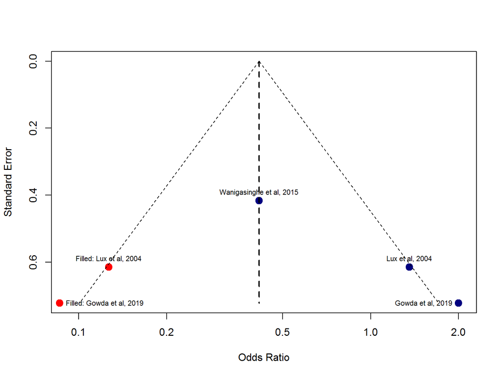

```r
# Funnel plot
funnel(DIRECT_COMPARISON_ACTH_PRD_trimandfill, comb.fixed = FALSE, comb.random = TRUE, pch = 21, cex = 1.5,
       lty.random = 2, lwd.random = 2,
       bg = c("navy", "navy", "navy", "red", "red"),
       col = c("navy", "navy", "navy", "red", "red"),
       studlab = TRUE, cex.studlab = 0.7, pos.studlab = c(3, 3, 2, 3, 4))
```

Obviously, “adjusting” for potential publication bias shows a more balanced plot. In red, the inputted study to compensate for potential publication bias.

#### Risk of bias for the meta-analysis of randomized trials

We evaluate risk of bias with the Cochrane Collaboration tool.

```r
# Data
Author <- c("Lux et al, 2004", "Wanigasinghe et al, 2015", "Gowda et al, 2019")
A_Random_sequence_generation____selection_bias <- c("Low", "Low", "Low")
B_Allocation_concealment____selection_bias <- c("Low", "Low", "Unclear")
C_Blinding_of_participants_and_personnel____performance_bias <- c("High", "High", "High")
D_Blinding_of_outcome_assessment____detection_bias <- c("Low", "Low", "Unclear")
E_Incomplete_outcome_data____attrition_bias <- c("Low", "Low", "Unclear")
F_Selective_reporting____reporting_bias <- c("Low", "Low", "Low")

riskofbias_df <- data.frame(Author, A_Random_sequence_generation____selection_bias, B_Allocation_concealment____selection_bias, C_Blinding_of_participants_and_personnel____performance_bias, D_Blinding_of_outcome_assessment____detection_bias, E_Incomplete_outcome_data____attrition_bias, F_Selective_reporting____reporting_bias)


######## DEFINE FUNCTION rob.summary from Mathias Harrer & David Daniel Ebert #############################
#' Create a RevMan-style risk of bias summary chart
#'
#' This function generates summary plots for study quality assessments using the
#' \href{https://bit.ly/2KGQtfG}{Cochrance Risk of Bias Tool}.
#' Summary plots follow the style of \href{https://bit.ly/30eJK29}{RevMan} RoB summary charts.
#'
#' @usage rob.summary(data, name.high="High", name.unclear="Unclear",
#'     name.low="Low", studies, name.missing, table = FALSE)
#'
#' @param data A \code{data.frame} containing a column for each risk of bias criterion, where
#' rows represent each individual studies. The risk of bias assessment for each criterion for each
#' study must be coded as a character string. Up to four codes can be used, referring to low risk of bias,
#' unclear risk of bias, high risk of bias, or missing information. The string used to specify the categories
#' must be specified in \code{name.high}, \code{name.unclear}, \code{name.low} and/or \code{name.missing},
#' unless defaults for those parameters are used.
#' @param name.high Character specifying how the "high risk of bias" category was coded in \code{data}
#' (e.g., \code{name.high = "high"}). Default is \code{"High"}.
#' @param name.unclear Character specifying how the "unclear risk of bias" category was coded in \code{data}
#' (e.g., \code{name.unclear = "unclear"}). Default is \code{"Unclear"}.
#' @param name.low Character specifying how the "low risk of bias" category was coded in \code{data}
#' (e.g., \code{name.low = "low"}). Default is \code{"Low"}.
#' @param name.missing Character specifying how missing information was coded in \code{data}
#' (e.g., \code{name.missing} = \code{"missing"}). Default is \code{"Missing"}. All ratings, including missing
#' information, must be coded as strings, so using \code{NA} in \code{data} to signify missing information
#' is not valid.
#' @param studies A vector of the same length as the number of rows in \code{data} specifying the study
#' labels for the risk of bias ratings. Only has to be specified when \code{table = TRUE}.
#' @param table Should an additional RevMan style risk of bias table be produced? If set to \code{TRUE},
#' \code{studies} must be specified. \code{FALSE} by default.
#'
#' @details The function automatically removes separators like "-" or "." from column names/risk of bias criteria. To produce
#' a "clean" plot, you may therefore separate words in the column names of the \code{data} data frame using these
#' symbols (e.g. \code{"Allocation_Concealment"} to return "Allocation Concealment").
#'
#' @references Harrer, M., Cuijpers, P., Furukawa, T.A, & Ebert, D. D. (2019).
#' \emph{Doing Meta-Analysis in R: A Hands-on Guide}. DOI: 10.5281/zenodo.2551803.
#' \href{https://bookdown.org/MathiasHarrer/Doing_Meta_Analysis_in_R/creating-a-revman-style-risk-of-bias-summary.html}{Chapter 10}
#'
#' @author Mathias Harrer & David Daniel Ebert
#'
#' @import ggplot2
#' @importFrom tidyr gather
#'
#' @export rob.summary
#'
#' @seealso
#' \code{\link{direct.evidence.plot}}
#'
#' @examples
#' # Example 1: No missing information, only produce summary plot
#' data = data.frame(
#'        "study" = c("Higgins et al., 2011", "Borenstein et al., 2008", "Holm, 1971",
#'                    "Zajonc et al., 2005", "Cuijpers, 2014"),
#'        "Allocation_concealment" = c("Low", "High", "High", "Unclear", "High"),
#'        "Randomization" = c("Low", "High", "Unclear", "Low", "High"),
#'        "Sequence_generation" = c("Low", "High", "Unclear", "Unclear", "High"),
#'        "ITT.Analyses" = c("Low", "High", "Unclear", "Unclear", "Unclear"),
#'        "Selective_outcome_reporting" = c("Low", "High", "High", "High", "Unclear")
#'        )
#' rob.summary(data)
#'
#' # Example 2: Missing information, produce additional summary table
#' data2 = data.frame(
#'         "study" = c("Higgins et al., 2011", "Borenstein et al., 2008", "Holm, 1971",
#'                     "Zajonc et al., 2005", "Cuijpers, 2014"),
#'         "Allocation_concealment" = c("low", "high", "high", "uc", "high"),
#'         "Randomization" = c("low", "high", "miss", "low", "high"),
#'         "Sequence_generation" = c("low", "high", "uc", "uc", "high"),
#'         "ITT.Analyses" = c("low", "high", "uc", "uc", "uc"),
#'         "Selective_outcome_reporting" = c("low", "high", "high", "high", "uc")
#'        )
#' rob.summary(data2, name.high = "high", name.unclear = "uc", name.low = "low",
#'     name.missing = "miss", studies = data2$study, table = TRUE)


rob.summary = function(data,
                       name.high="High",
                       name.unclear="Unclear",
                       name.low="Low",
                       studies,
                       name.missing,
                       table = FALSE){

  # Class Checks
  if (class(data) != "data.frame"){
    stop("'data' must be of class 'data.frame'.")
  }


  if (missing(name.missing)){

    # Only select columns with RoB data

    colnames.rob = character()

    for (i in 1:ncol(data)){

      vect = as.character(data[,i])

      for (j in 1:length(data[,i])){
```

```r
        if (vect[j] %in% c(name.high, name.unclear, name.low)){

          colnames.rob[i] = TRUE

        } else {

          colnames.rob[i] = FALSE
          message(cat("Column '", colnames(data)[i],
                      "' removed from plot because it did not contain the specified RoB ratings (only). \n",
                      sep=""))
          break

        }
      }
    }

    # Use mask: rob data
    rob = data[ , as.logical(colnames.rob)]

    # Relevel for plot
    for (i in 1:ncol(rob)){

      rob[,i] = as.character(rob[,i])
      rob[rob[,i]==name.high,i] = "High"
      rob[rob[,i]==name.unclear,i] = "Unclear"
      rob[rob[,i]==name.low,i] = "Low"

    }

    # Make table
    if (table == TRUE){

      if (missing(studies)){
        stop("'studies' has to be specified when 'table = TRUE'.")
      }

      if (length(as.vector(studies)) != nrow(data)){
        stop("'studies' vector is not of equal length as the data.")
      }

      robby = rob
      robby$study = studies
      robby = gather(robby, condition, measurement, -study)
      robby$condition = gsub("_"," ", robby$condition)
      robby$condition = gsub("-"," ", robby$condition)
      robby$condition = gsub("\\."," ", robby$condition)
      robby[robby$measurement=="Low", "measurement"] = "+"
      robby[robby$measurement=="Unclear", "measurement"] = "?"
      robby[robby$measurement=="High", "measurement"] = "-"

      rob.table = ggplot(data = robby, aes(y = condition, x = study)) +
        geom_tile(color="black", fill="white", size = 0.8) +
        geom_point(aes(color=as.factor(measurement)), size=20) +
        geom_text(aes(label = measurement), size = 8) +
        scale_x_discrete(position = "top") +
        scale_color_manual(values = c("?" = "#E2DF07",
                                      "-" = "#BF0000",
                                      "+" = "#02C100")) +
        theme_minimal() +
        coord_equal() +
        theme(axis.title.x = element_blank(),
              axis.title.y = element_blank(),
              axis.ticks.y = element_blank(),
              axis.text.y = element_text(size = 15, color = "black"),
              axis.text.x = element_text(size = 13, color = "black", angle = 90, hjust=0),
              legend.position = "none",
              panel.grid.major = element_blank(),
              panel.grid.minor = element_blank(),
              panel.background = element_blank())

    }

    # Make long format, clean the factors
    rob.long = gather(rob, condition, measurement, factor_key = TRUE)
    rob.long$condition = gsub("_"," ",rob.long$condition)
    rob.long$condition = gsub("-"," ",rob.long$condition)
    rob.long$condition = gsub("\\."," ",rob.long$condition)
    rob.long$measurement = as.factor(rob.long$measurement)
    rob.long$measurement = factor(rob.long$measurement, levels(rob.long$measurement)[c(1, 3, 2)])

    # Make plot
    rob.plot = ggplot(data = rob.long) +
      geom_bar(mapping = aes(x = condition, fill = measurement), width = 0.7,
               position = "fill", color = "black") +
      coord_flip(ylim = c(0, 1)) +
      guides(fill = guide_legend(reverse = TRUE)) +
      scale_fill_manual("Risk of Bias",
                        labels = c("    High risk of bias          ",
                                   "    Unclear risk of bias       ",
                                   "    Low risk of bias  "),
                        values = c(Unclear = "#E2DF07", High = "#BF0000", Low = "#02C100")) +
      scale_y_continuous(labels = scales::percent) +
      theme(axis.title.x = element_blank(),
            axis.title.y = element_blank(),
            axis.ticks.y = element_blank(),
            axis.text.y = element_text(size = 18, color = "black"),
            axis.line.x = element_line(colour = "black", size = 0.5, linetype = "solid"),
            legend.position = "bottom",
            panel.grid.major = element_blank(),
            panel.grid.minor = element_blank(),
            panel.background = element_blank(),
            legend.background = element_rect(linetype = "solid", colour = "black"),
            legend.title = element_blank(),
            legend.key.size = unit(0.75, "cm"),
            legend.text = element_text(size = 14))

    plot(rob.plot)

    if (table == TRUE){
      plot(rob.table)
    }

  } else {

    # Only select columns with RoB data
    data = as.data.frame(data)

    colnames.rob = character()

    for (i in 1:ncol(data)){

      vect = as.character(data[,i])

      for (j in 1:length(data[,i])){

        if (vect[j] %in% c(name.high, name.unclear, name.low, name.missing)){

          colnames.rob[i] = TRUE

        } else {

          colnames.rob[i] = FALSE
          message(cat("Column '", colnames(data)[i],
                      "' removed from plot because it did not contain the specified RoB ratings (only). \n",
                      sep=""))
          break

        }
      }
    }

    # Use mask: rob data
    rob = data[ , as.logical(colnames.rob)]

    # Relevel for plot
    for (i in 1:ncol(rob)){

      rob[,i] = as.character(rob[,i])
      rob[rob[,i]==name.high,i] = "High"
      rob[rob[,i]==name.unclear,i] = "Unclear"
      rob[rob[,i]==name.low,i] = "Low"
      rob[rob[,i]==name.missing,i] = "Missing"

    }

    # Make Table

    if (table == TRUE){

      if (missing(studies)){
        stop("'studies' has to be specified when 'table = TRUE'.")
      }

      if (length(as.vector(studies)) != nrow(data)){
        stop("'studies' vector is not of equal length as the data.")
      }

      robby = rob
      robby$study = studies
      robby = gather(robby, condition, measurement, -study)
      robby$condition = gsub("_"," ", robby$condition)
      robby$condition = gsub("-"," ", robby$condition)
      robby$condition = gsub("\\."," ", robby$condition)
      robby[robby$measurement=="Low", "measurement"] = "+"
      robby[robby$measurement=="Unclear", "measurement"] = "?"
      robby[robby$measurement=="High", "measurement"] = "-"
      robby[robby$measurement=="Missing", "measurement"] = " "
```

```
## Column 'Author' removed from plot because it did not contain the specified RoB ratings (only).
```

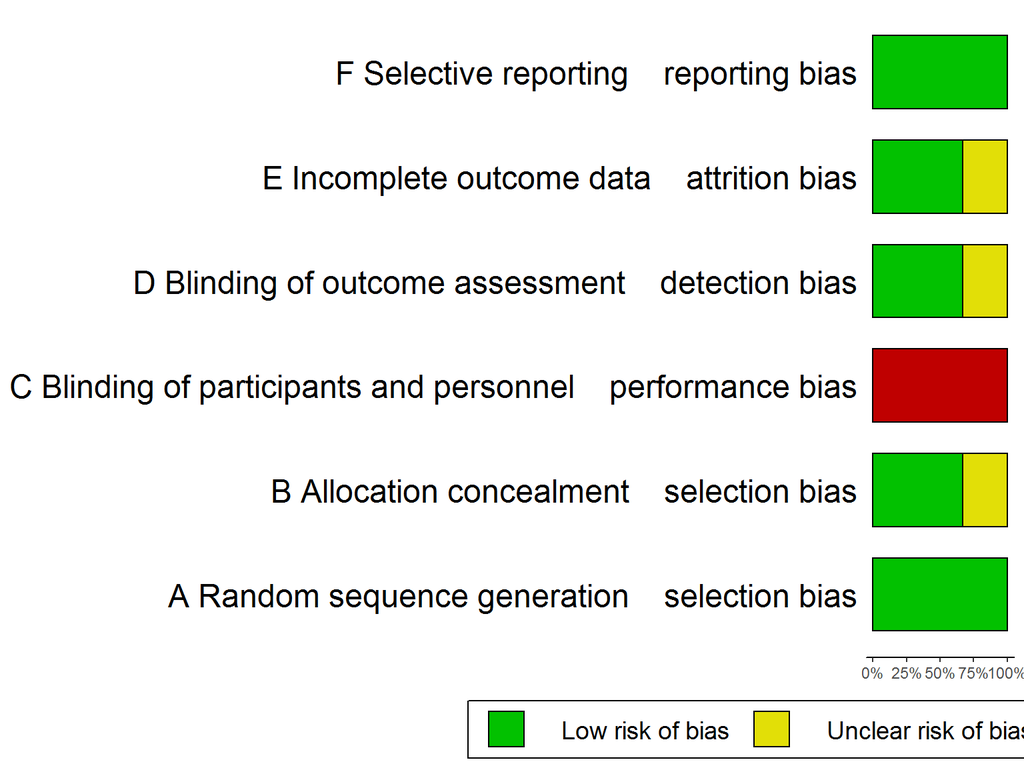

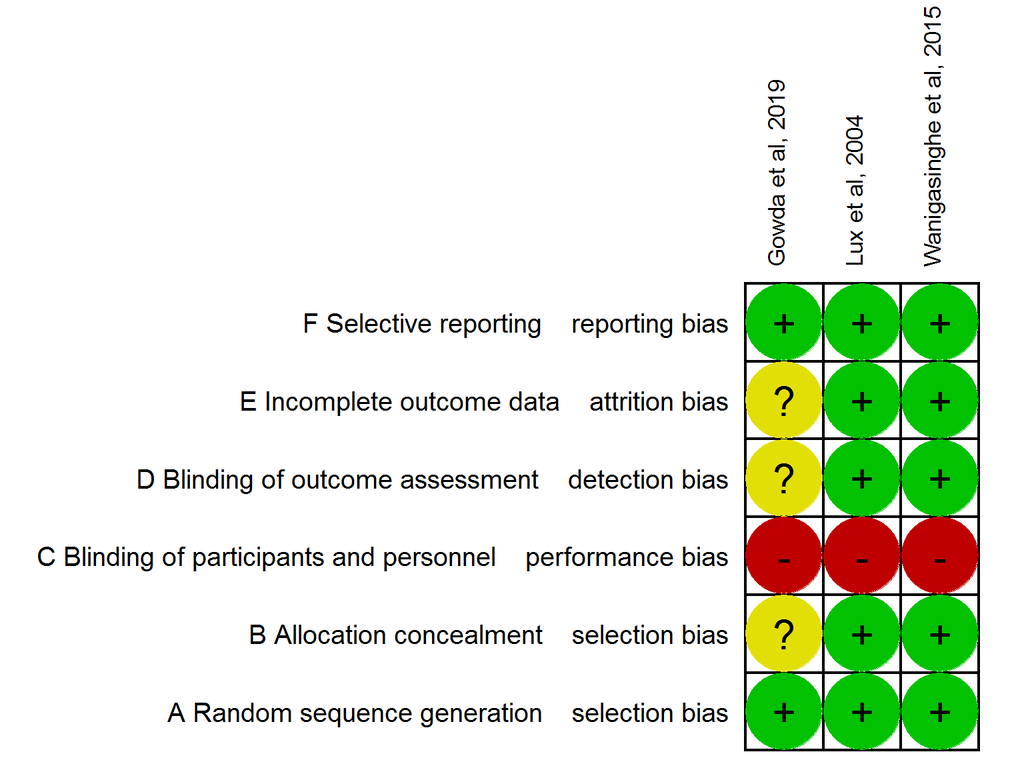

```r
      rob.table = ggplot(data = robby, aes(y = condition, x = study)) +
        geom_tile(color="black", fill="white", size = 0.8) +
        geom_point(aes(color=as.factor(measurement)), size=20) +
        geom_text(aes(label = measurement), size = 8) +
        scale_x_discrete(position = "top") +
        scale_color_manual(values = c("?" = "#E2DF07",
                                      "-" = "#BF0000",
                                      "+" = "#02C100",
                                      " " = "white")) +
        theme_minimal() +
        coord_equal() +
        theme(axis.title.x = element_blank(),
              axis.title.y = element_blank(),
              axis.ticks.y = element_blank(),
              axis.text.y = element_text(size = 15, color = "black"),
              axis.text.x = element_text(size = 13, color = "black", angle = 90, hjust=0),
              legend.position = "none",
              panel.grid.major = element_blank(),
              panel.grid.minor = element_blank(),
              panel.background = element_blank())

    }

    # Make long format, clean the factors
    rob.long = gather(rob, condition, measurement, factor_key = TRUE)
    rob.long$condition = gsub("_"," ",rob.long$condition)
    rob.long$condition = gsub("-"," ",rob.long$condition)
    rob.long$condition = gsub("\\."," ",rob.long$condition)
    rob.long$measurement = as.factor(rob.long$measurement)
    rob.long$measurement = factor(rob.long$measurement, levels(rob.long$measurement)[c(3,1,4,2)])

    rob.plot = ggplot(data = rob.long) +
      geom_bar(mapping = aes(x = condition, fill = measurement), width = 0.7,
               position = "fill", color = "black") +
      coord_flip(ylim = c(0, 1)) +
      guides(fill = guide_legend(reverse = TRUE)) +
      scale_fill_manual("Risk of Bias",
                        labels = c("  Missing information  ",
                                   "  High risk of bias   ",
                                   "  Unclear risk of bias  ",
                                   "  Low risk of bias  "),
                        values = c(Unclear = "#E2DF07",
                                   High = "#BF0000",
                                   Low = "#02C100",
                                   Missing = "white")) +
      scale_y_continuous(labels = scales::percent) +
      theme(axis.title.x = element_blank(),
            axis.title.y = element_blank(),
            axis.ticks.y = element_blank(),
            axis.text.y = element_text(size = 18, color = "black"),
            axis.line.x = element_line(colour = "black", size = 0.5, linetype = "solid"),
            legend.position = "bottom",
            panel.grid.major = element_blank(),
            panel.grid.minor = element_blank(),
            panel.background = element_blank(),
            legend.background = element_rect(linetype = "solid", colour = "black"),
            legend.title = element_blank(),
            legend.key.size = unit(0.75, "cm"),
            legend.text = element_text(size = 14))

    plot(rob.plot)

    if (table == TRUE){
      plot(rob.table)
    }

  }

}
######## DEFINE FUNCTION rob.summary from Mathias Harrer & David Daniel Ebert #############################


## Generate the graphs
rob.summary(riskofbias_df, studies = riskofbias_df$Author, table = TRUE)
```